# Statistical Methods for Microbiome Analysis

Malu Calle, University of Vic - Central University of Catalonia

[figure not shown]

This tutorial is based on several phyloseq tutorials that are available at https://joey711.github.io/phyloseq/

# 1 Elements of a phyloseq object

Make a copy of default graphical settings:

```r
default.par <- par()
#par(default.par)   # recover default graphical settings
```

Load libraries phyloseq and vegan:

```r
# BiocManager::install("phyloseq")
library(phyloseq)
#install.packages("vegan")
library(vegan)
```

Load microbiome dataset “GlobalPatterns”:

```r
data(GlobalPatterns)
```

Information on dataset “GlobalPatterns”:

```r
?GlobalPatterns
```

Elements of phyloseq object “GlobalPatterns”:

```r
GlobalPatterns
```

```
## phyloseq-class experiment-level object
## otu_table()   OTU Table:         [ 19216 taxa and 26 samples ]
## sample_data() Sample Data:       [ 26 samples by 7 sample variables ]
## tax_table()   Taxonomy Table:    [ 19216 taxa by 7 taxonomic ranks ]
## phy_tree()    Phylogenetic Tree: [ 19216 tips and 19215 internal nodes ]
```

Rename phyloseq object “GlobalPatterns” as “data”:

```r
data<-GlobalPatterns
```

Dimension of OTU table:

```r
dim(data@otu_table)
```

```
## [1] 19216    26
```

First rows of OTU table:

```r
head(data@otu_table)
```

```
## OTU Table:          [6 taxa and 26 samples]
##                      taxa are rows
##        CL3 CC1 SV1 M31Fcsw M11Fcsw M31Plmr M11Plmr F21Plmr M31Tong M11Tong
## 549322   0   0   0       0       0       0       0       0       0       0
## 522457   0   0   0       0       0       0       0       0       0       0
## 951      0   0   0       0       0       0       1       0       0       0
## 244423   0   0   0       0       0       0       0       0       0       0
## 586076   0   0   0       0       0       0       0       0       0       0
## 246140   0   0   0       0       0       0       0       0       0       0
##        LMEpi24M SLEpi20M AQC1cm AQC4cm AQC7cm NP2 NP3 NP5 TRRsed1 TRRsed2
## 549322        0        1     27    100    130   1   0   0       0       0
## 522457        0        0      0      2      6   0   0   0       0       0
## 951           0        0      0      0      0   0   0   0       0       0
## 244423        0        0      0     22     29   0   0   0       0       0
## 586076        0        0      0      2      1   0   0   0       0       0
## 246140        0        0      0      1      3   0   0   0       0       0
##        TRRsed3 TS28 TS29 Even1 Even2 Even3
## 549322       0    0    0     0     0     0
## 522457       0    0    0     0     0     0
## 951          0    0    0     0     0     0
## 244423       0    0    0     0     0     0
## 586076       0    0    0     0     0     0
## 246140       0    0    0     0     0     0
```

Proportion of zeros in OTU table:

```r
sum(data@otu_table==0)/(ntaxa(data)*nsamples(data))
```

```
## [1] 0.7906832
```

Dimension of taxonomy table:

```r
dim(data@tax_table)
```

```
## [1] 19216     7
```

First rows of taxonomy table:

```r
head(data@tax_table)
```

```
## Taxonomy Table:     [6 taxa by 7 taxonomic ranks]:
##        Kingdom   Phylum          Class          Order          Family
## 549322 "Archaea" "Crenarchaeota" "Thermoprotei" NA             NA
## 522457 "Archaea" "Crenarchaeota" "Thermoprotei" NA             NA
## 951    "Archaea" "Crenarchaeota" "Thermoprotei" "Sulfolobales" "Sulfolobaceae"
## 244423 "Archaea" "Crenarchaeota" "Sd-NA"        NA             NA
## 586076 "Archaea" "Crenarchaeota" "Sd-NA"        NA             NA
## 246140 "Archaea" "Crenarchaeota" "Sd-NA"        NA             NA
##        Genus        Species
## 549322 NA           NA
## 522457 NA           NA
## 951    "Sulfolobus" "Sulfolobusacidocaldarius"
## 244423 NA           NA
## 586076 NA           NA
## 246140 NA           NA
```

Dimension of dataframe sample_data:

```r
dim(data@sam_data)
```

```
## [1] 26  7
```

Names of variables in dataframe sample_data:

```r
colnames(data@sam_data)
```

```
## [1] "X.SampleID"               "Primer"
## [3] "Final_Barcode"            "Barcode_truncated_plus_T"
## [5] "Barcode_full_length"      "SampleType"
## [7] "Description"
```

Summary of variables in dataframe sample_data:

```r
summary(data@sam_data)
```

```
##    X.SampleID     Primer   Final_Barcode Barcode_truncated_plus_T
##  AQC1cm : 1   ILBC_01: 1   AACGCA : 1    AACTGT : 1
##  AQC4cm : 1   ILBC_02: 1   AACTCG : 1    ACAGGT : 1
##  AQC7cm : 1   ILBC_03: 1   AACTGT : 1    ACAGTT : 1
##  CC1    : 1   ILBC_04: 1   AAGAGA : 1    ACATGT : 1
##  CL3    : 1   ILBC_05: 1   AAGCTG : 1    ACGATT : 1
##  Even1  : 1   ILBC_07: 1   AATCGT : 1    AGCTGT : 1
##  (Other):20   (Other):20   (Other):20    (Other):20
##   Barcode_full_length              SampleType
##  AGAGAGACAGG: 1       Feces             :4
##  AGCCGACTCTG: 1       Freshwater (creek):3
##  ATGAAGCACTG: 1       Mock              :3
##  CAAGCTAGCTG: 1       Ocean             :3
##  CACGTGACATG: 1       Sediment (estuary):3
##  CATCGACGAGT: 1       Skin              :3
##  (Other)    :20       (Other)           :7
##                                    Description
##  Tijuana River Reserve, depth 2          : 2
##  Allequash Creek, 0-1cm depth            : 1
##  Allequash Creek, 3-4 cm depth           : 1
##  Allequash Creek, 6-7 cm depth           : 1
##  Calhoun South Carolina Pine soil, pH 4.9: 1
##  Cedar Creek Minnesota, grassland, pH 6.1: 1
##  (Other)                                 :19
```

Summary of variable “SampleType”:

```r
table(sample_data(data)$SampleType)
```

```
##
##              Feces         Freshwater Freshwater (creek)               Mock
##                  4                  2                  3                  3
##              Ocean Sediment (estuary)               Skin               Soil
##                  3                  3                  3                  3
##             Tongue
##                  2
```

Define a new factor variable called “human” that indicates which samples corresponde to human samples (feces, skin and tongue):

```r
human.samples<-c("Feces", "Skin", "Tongue")
sample_data(data)$human<-rep(0,26)
sample_data(data)$human[sample_data(data)$SampleType%in%human.samples]<-1
sample_data(data)$human<-factor(sample_data(data)$human,levels=c(0,1),labels=c("No","Yes"))
```

Define a new dataframe called “metadata” that includes variables “X.SampleID”, “SampleType”, “Description” and “human”:

```r
metadata<-as.data.frame(data@sam_data[,c(1,6,7,8)])
```

Summary of dataframe “metadata”:

```r
summary(metadata)
```

```
##    X.SampleID              SampleType
##  AQC1cm : 1   Feces             :4
##  AQC4cm : 1   Freshwater (creek):3
##  AQC7cm : 1   Mock              :3
##  CC1    : 1   Ocean             :3
##  CL3    : 1   Sediment (estuary):3
##  Even1  : 1   Skin              :3
##  (Other):20   (Other)           :7
##                                    Description human
##  Tijuana River Reserve, depth 2          : 2   No :17
##  Allequash Creek, 0-1cm depth            : 1   Yes: 9
##  Allequash Creek, 3-4 cm depth           : 1
##  Allequash Creek, 6-7 cm depth           : 1
##  Calhoun South Carolina Pine soil, pH 4.9: 1
##  Cedar Creek Minnesota, grassland, pH 6.1: 1
##  (Other)                                 :19
```

# 2 Phyloseq accessors

## 2.1 nsamples(physeq)

Number of samples in phyloseq object “data”:

```r
nsamples(data)
```

```
## [1] 26
```

## 2.2 ntaxa(physeq)

Number of taxa or species in phyloseq object “data”:

```r
ntaxa(data)
```

```
## [1] 19216
```

## 2.3 sample_names

Names of the samples in phyloseq object “data”:

```r
sample_names(data)[1:5]
```

```
## [1] "CL3"     "CC1"     "SV1"     "M31Fcsw" "M11Fcsw"
```

## 2.4 taxa_names

Names of taxa (OTUs, species) in phyloseq object “data”:

```r
taxa_names(data)[1:5]
```

```
## [1] "549322" "522457" "951"    "244423" "586076"
```

## 2.5 rank_names

Names of the taxonomic ranks in phyloseq object “data”:

```r
rank_names(data)
```

```
## [1] "Kingdom" "Phylum"  "Class"   "Order"   "Family"  "Genus"   "Species"
```

## 2.6 get_taxa(physeq, i)

Returns all abundance values of sample i:

```r
get_taxa(data,4)[1:5]
```

```
## 549322 522457    951 244423 586076
##      0      0      0      0      0
```

## 2.7 get_sample(physeq, i)

Returns all abundance values for species i:

```r
get_sample(data,2)[1:3]
```

```
## CL3 CC1 SV1
##   0   0   0
```

## 2.8 sample_sums

Summary of total number of counts per sample:

```r
summary(sample_sums(data))
```

```
##    Min. 1st Qu.  Median    Mean 3rd Qu.    Max.
##   58688  567103 1106849 1085257 1527330 2357181
```

Histogram of the total number of counts per sample:

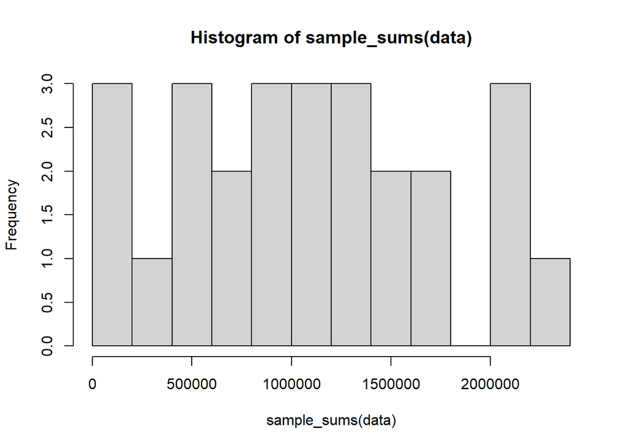

```r
hist(sample_sums(data), breaks=10)
```

Boxplot of log(total number of counts per sample) by sample type:

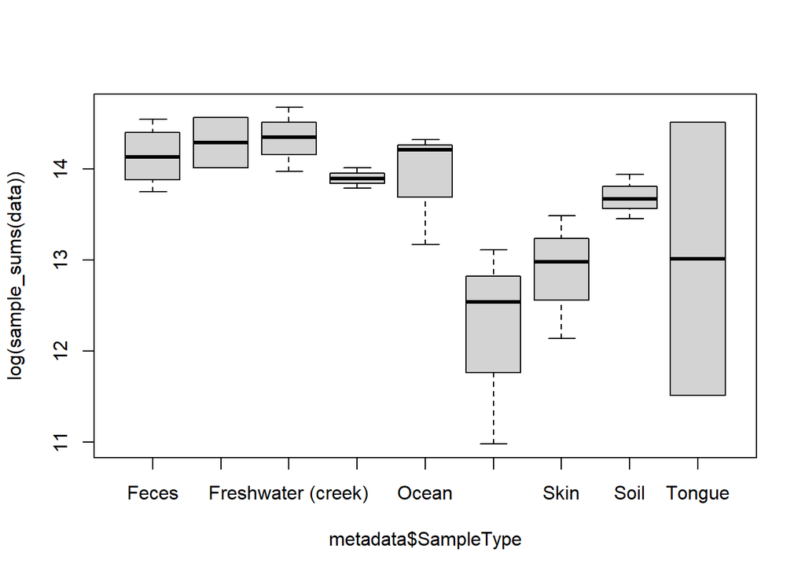

```r
boxplot(log(sample_sums(data))~metadata$SampleType)
```

## 2.9 taxa_sums

Summary of total number of counts per taxa:

```r
summary(taxa_sums(data))
```

```
##    Min. 1st Qu.  Median    Mean 3rd Qu.    Max.
##       0       4      27    1468     198 2481214
```

Histogram of total number of counts per taxa:

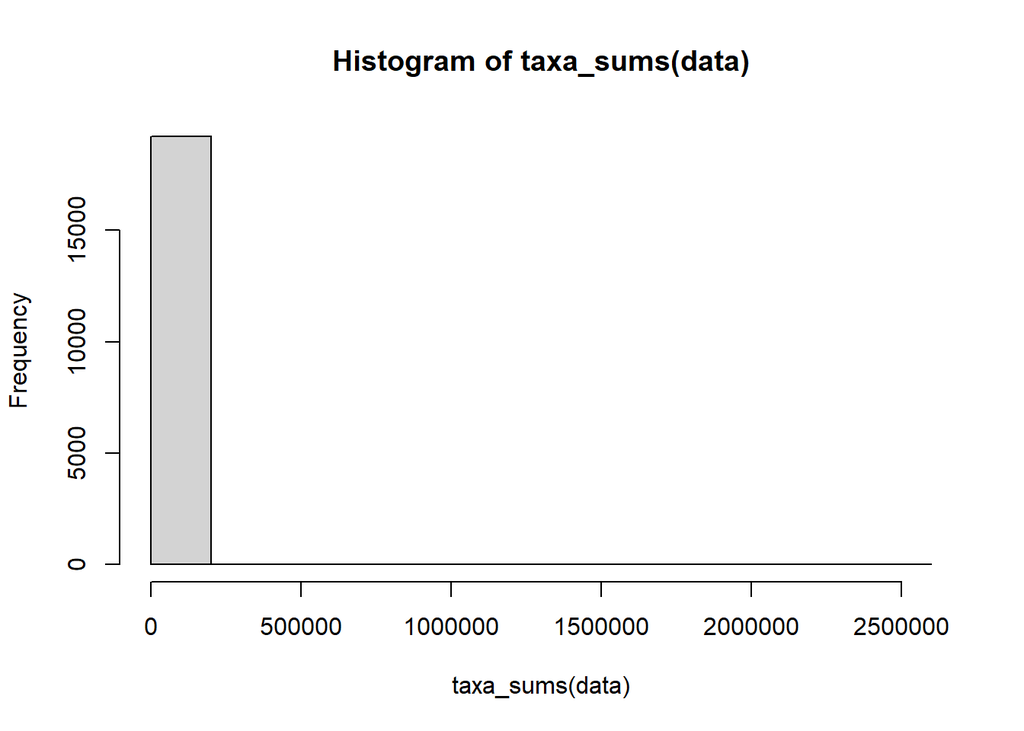

```r
hist(taxa_sums(data))
```

Histogram of log(total number of counts per taxa):

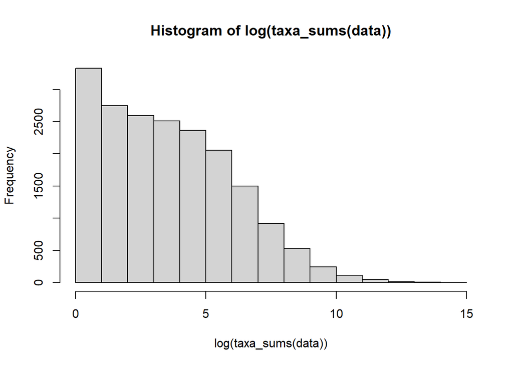

```r
hist(log(taxa_sums(data)))
```

# 3 Preprocessing

## 3.1 prune_taxa

Specification of condition for those taxa you want to keep.

*Example*: Keep only those taxa with at least 10 counts:

```r
data<-prune_taxa(taxa_sums(data)>10, data)
```

Summary of total number of counts per taxa after taxa pruning:

```r
summary(taxa_sums(data))
```

```
##    Min. 1st Qu.  Median    Mean 3rd Qu.    Max.
##      11      34     113    2339     498 2481214
```

## 3.2 prune_samples

Specification of condition for those samples you want to keep.

*Example*: Keep only those samples with at least 10 counts:

```r
data<-prune_samples(sample_sums(data)>10, data)
```

## 3.3 rarefaction: rarefy_even_depth()

Resample an OTU table such that all samples have the same library size.

*Example*: Create a new phyloseq object called “raredata” with all samples having the same library size, equal to the minimum of total number of counts per sample, using a random seed equal to “123”:

```r
raredata<-rarefy_even_depth(data, sample.size = min(sample_sums(data)), rngseed = 123)
```

```
## `set.seed(123)` was used to initialize repeatable random subsampling.
```

```
## Please record this for your records so others can reproduce.
```

```
## Try `set.seed(123); .Random.seed` for the full vector
```

```
## ...
```

```
## 1067OTUs were removed because they are no longer
## present in any sample after random subsampling
```

```
## ...
```

Number of OTUs removed after rarefaction:

```r
ntaxa(data)-ntaxa(raredata)
```

```
## [1] 1067
```

## 3.4 transform_sample_counts

Transform counts in an otu_table, sample-by-sample:

*Example*: Create a new phyloseq object called “propdata” with relative abundances:

```r
propdata<-transform_sample_counts(data, function(x) x/sum(x))
```

Check that the total count per sample of “propdata” is 1:

```r
sample_sums(propdata)
```

```
##      CL3      CC1      SV1  M31Fcsw  M11Fcsw  M31Plmr  M11Plmr  F21Plmr
##        1        1        1        1        1        1        1        1
##  M31Tong  M11Tong LMEpi24M SLEpi20M   AQC1cm   AQC4cm   AQC7cm      NP2
##        1        1        1        1        1        1        1        1
##      NP3      NP5  TRRsed1  TRRsed2  TRRsed3     TS28     TS29    Even1
##        1        1        1        1        1        1        1        1
##    Even2    Even3
##        1        1
```

## 3.5 tax_glom

Agglomerate taxa at some taxonomic level.

*Example*: Create a new phyloseq object called “dataKingdom” with abundance data at Kingdom level:

```r
dataKingdom<-tax_glom(data, "Kingdom")
```

Elements of phyloseq object “dataKingdom”:

```r
dataKingdom
```

```
## phyloseq-class experiment-level object
## otu_table()   OTU Table:         [ 2 taxa and 26 samples ]
## sample_data() Sample Data:       [ 26 samples by 8 sample variables ]
## tax_table()   Taxonomy Table:    [ 2 taxa by 7 taxonomic ranks ]
## phy_tree()    Phylogenetic Tree: [ 2 tips and 1 internal nodes ]
```

Though the “dataKingdom”" is aglommerated at Kingdom level, the taxa names remain at OTU level:

```r
taxa_names(dataKingdom)
```

```
## [1] "250392" "549656"
```

Redifine taxa names with Kingdom levels:

```r
taxa_names(dataKingdom)<-as.vector(dataKingdom@tax_table[,1])
taxa_names(dataKingdom)
```

```
## [1] "Archaea"  "Bacteria"
```

*Example*: Create a new phyloseq object called “propdataKingdom” with relative abundance data at Kingdom level:

```r
propdataKingdom<-tax_glom(propdata, rank_names(data)[1])
propdataKingdom
```

```
## phyloseq-class experiment-level object
## otu_table()   OTU Table:         [ 2 taxa and 26 samples ]
## sample_data() Sample Data:       [ 26 samples by 8 sample variables ]
## tax_table()   Taxonomy Table:    [ 2 taxa by 7 taxonomic ranks ]
## phy_tree()    Phylogenetic Tree: [ 2 tips and 1 internal nodes ]
```

*Example*: Create a new phyloseq object called “dataPhylum” with abundance data at Phylum level:

```r
dataPhylum<-tax_glom(data, rank_names(data)[2])
dataPhylum
```

```
## phyloseq-class experiment-level object
## otu_table()   OTU Table:         [ 60 taxa and 26 samples ]
## sample_data() Sample Data:       [ 26 samples by 8 sample variables ]
## tax_table()   Taxonomy Table:    [ 60 taxa by 7 taxonomic ranks ]
## phy_tree()    Phylogenetic Tree: [ 60 tips and 59 internal nodes ]
```

*Example*: Create a new phyloseq object called “propdataPhylum” with relative abundance data at Phylum level:

```r
propdataPhylum<-tax_glom(propdata, rank_names(data)[2])
propdataPhylum
```

```
## phyloseq-class experiment-level object
## otu_table()   OTU Table:         [ 60 taxa and 26 samples ]
## sample_data() Sample Data:       [ 26 samples by 8 sample variables ]
## tax_table()   Taxonomy Table:    [ 60 taxa by 7 taxonomic ranks ]
## phy_tree()    Phylogenetic Tree: [ 60 tips and 59 internal nodes ]
```

Redifine taxa names with Phylum levels:

```r
taxa_names(propdataPhylum)<-tax_table(propdataPhylum)[,2]
```

## 3.6 merge_taxa

Merge a subset of the species into one taxa.

*Example*: Merge those taxa with total relative abundance smaller than 0.8 into a new taxa:

Number of taxa with with total relative abundance smaller than 0.8:

```r
sum(taxa_sums(propdataPhylum)<0.8)
```

```
## [1] 55
```

Define a vector of indices called “less_freq_taxa” corresponding to those taxa with total relative abundance smaller than 0.8:

```r
less_freq_taxa<-which(taxa_sums(propdataPhylum)<0.8)
```

Define a new phyloseq object called “propdataPhylum2” with those taxa with total relative abundance smaller than 0.8 merged:

```r
propdataPhylum2<-merge_taxa(propdataPhylum,less_freq_taxa)
```

OTU table of less frequent taxa merged:

```r
otu_table(propdataPhylum2)
```

```
## OTU Table:          [6 taxa and 26 samples]
##                      taxa are rows
##                        CL3         CC1         SV1      M31Fcsw      M11Fcsw
## Actinobacteria 0.045711043 0.079457234 0.174421596 0.0016460238 0.0004047202
## Cyanobacteria  0.002248122 0.002934656 0.023887856 0.0002742293 0.1025300794
## Proteobacteria 0.340928821 0.318121962 0.321418151 0.0121795391 0.0417208703
## Bacteroidetes  0.077895052 0.084876418 0.133990465 0.5214342903 0.6860508367
## OP3            0.524178048 0.510764228 0.341725704 0.0111455068 0.0104398538
## Firmicutes     0.009030789 0.003799607 0.004461366 0.4533204106 0.1588536397
##                   M31Plmr    M11Plmr    F21Plmr     M31Tong    M11Tong
## Actinobacteria 0.11931410 0.23754124 0.14636890 0.061700229 0.08807079
## Cyanobacteria  0.02175058 0.07545949 0.04229248 0.003366958 0.12881028
## Proteobacteria 0.21890686 0.49148008 0.24934750 0.672479094 0.21743039
## Bacteroidetes  0.08941594 0.03831884 0.14499664 0.097393283 0.14812632
## OP3            0.07753160 0.01831274 0.10917261 0.057132786 0.09220566
## Firmicutes     0.47307954 0.13888530 0.30782188 0.107927651 0.32534657
##                   LMEpi24M     SLEpi20M     AQC1cm      AQC4cm      AQC7cm
## Actinobacteria 0.209976240 0.5325130727 0.02259572 0.011674379 0.017831796
## Cyanobacteria  0.526413419 0.0771706268 0.64711039 0.675046280 0.556147541
## Proteobacteria 0.139434491 0.1945401607 0.15686925 0.170501881 0.230508768
## Bacteroidetes  0.096990595 0.1414152454 0.04199690 0.046584601 0.063306527
## OP3            0.025221655 0.0539023330 0.12115860 0.091905065 0.127506529
## Firmicutes     0.001963128 0.0004577396 0.01025372 0.004263598 0.004678814
##                         NP2          NP3         NP5    TRRsed1     TRRsed2
## Actinobacteria 0.0382954411 0.0132399956 0.102149851 0.01810017 0.004418424
## Cyanobacteria  0.2391969824 0.0576600318 0.278751192 0.04655804 0.048114440
## Proteobacteria 0.4691339624 0.3610998319 0.309332768 0.60451472 0.816566242
## Bacteroidetes  0.1705934733 0.5195892921 0.245311824 0.10560727 0.042373743
## OP3            0.0823005163 0.0478078617 0.063206768 0.20142461 0.084491169
## Firmicutes     0.0004796246 0.0006016334 0.001246992 0.02281447 0.003323989
##                    TRRsed3         TS28        TS29       Even1        Even2
## Actinobacteria 0.008246674 0.0294299764 0.107526526 0.086808558 0.0816431859
## Cyanobacteria  0.002730925 0.0005295197 0.001761538 0.003331609 0.0006562112
## Proteobacteria 0.712491107 0.0049503682 0.004179108 0.201487460 0.1999651806
## Bacteroidetes  0.061621882 0.1506365979 0.051553078 0.252213463 0.2530564816
## OP3            0.166015078 0.0614915373 0.007908744 0.057488757 0.0393675236
## Firmicutes     0.048772162 0.7529620006 0.827071005 0.398670153 0.4253114170
##                       Even3
## Actinobacteria 0.0834566454
## Cyanobacteria  0.0009602102
## Proteobacteria 0.2013936500
## Bacteroidetes  0.2441012015
## OP3            0.0517465156
## Firmicutes     0.4183417773
```

Rename less frequent taxa name as “rare”:

```r
taxa_names(propdataPhylum2)[taxa_names(propdataPhylum2)
      %in%taxa_names(propdataPhylum)[less_freq_taxa]]<-"rare"
```

OTU table of less frequent taxa merged:

```r
otu_table(propdataPhylum2)
```

```
## OTU Table:          [6 taxa and 26 samples]
##                      taxa are rows
##                        CL3         CC1         SV1      M31Fcsw      M11Fcsw
## Actinobacteria 0.045711043 0.079457234 0.174421596 0.0016460238 0.0004047202
## Cyanobacteria  0.002248122 0.002934656 0.023887856 0.0002742293 0.1025300794
## Proteobacteria 0.340928821 0.318121962 0.321418151 0.0121795391 0.0417208703
## Bacteroidetes  0.077895052 0.084876418 0.133990465 0.5214342903 0.6860508367
## rare           0.524178048 0.510764228 0.341725704 0.0111455068 0.0104398538
## Firmicutes     0.009030789 0.003799607 0.004461366 0.4533204106 0.1588536397
##                   M31Plmr    M11Plmr    F21Plmr     M31Tong    M11Tong
## Actinobacteria 0.11931410 0.23754124 0.14636890 0.061700229 0.08807079
## Cyanobacteria  0.02175058 0.07545949 0.04229248 0.003366958 0.12881028
## Proteobacteria 0.21890686 0.49148008 0.24934750 0.672479094 0.21743039
## Bacteroidetes  0.08941594 0.03831884 0.14499664 0.097393283 0.14812632
## rare           0.07753160 0.01831274 0.10917261 0.057132786 0.09220566
## Firmicutes     0.47307954 0.13888530 0.30782188 0.107927651 0.32534657
##                   LMEpi24M     SLEpi20M     AQC1cm      AQC4cm      AQC7cm
## Actinobacteria 0.209976240 0.5325130727 0.02259572 0.011674379 0.017831796
## Cyanobacteria  0.526413419 0.0771706268 0.64711039 0.675046280 0.556147541
## Proteobacteria 0.139434491 0.1945401607 0.15686925 0.170501881 0.230508768
## Bacteroidetes  0.096990595 0.1414152454 0.04199690 0.046584601 0.063306527
## rare           0.025221655 0.0539023330 0.12115860 0.091905065 0.127506529
## Firmicutes     0.001963128 0.0004577396 0.01025372 0.004263598 0.004678814
##                         NP2          NP3         NP5    TRRsed1     TRRsed2
## Actinobacteria 0.0382954411 0.0132399956 0.102149851 0.01810017 0.004418424
## Cyanobacteria  0.2391969824 0.0576600318 0.278751192 0.04655804 0.048114440
## Proteobacteria 0.4691339624 0.3610998319 0.309332768 0.60451472 0.816566242
## Bacteroidetes  0.1705934733 0.5195892921 0.245311824 0.10560727 0.042373743
## rare           0.0823005163 0.0478078617 0.063206768 0.20142461 0.084491169
## Firmicutes     0.0004796246 0.0006016334 0.001246992 0.02281447 0.003323989
##                    TRRsed3         TS28        TS29       Even1        Even2
## Actinobacteria 0.008246674 0.0294299764 0.107526526 0.086808558 0.0816431859
## Cyanobacteria  0.002730925 0.0005295197 0.001761538 0.003331609 0.0006562112
## Proteobacteria 0.712491107 0.0049503682 0.004179108 0.201487460 0.1999651806
## Bacteroidetes  0.061621882 0.1506365979 0.051553078 0.252213463 0.2530564816
## rare           0.166015078 0.0614915373 0.007908744 0.057488757 0.0393675236
## Firmicutes     0.048772162 0.7529620006 0.827071005 0.398670153 0.4253114170
##                       Even3
## Actinobacteria 0.0834566454
## Cyanobacteria  0.0009602102
## Proteobacteria 0.2013936500
## Bacteroidetes  0.2441012015
## rare           0.0517465156
## Firmicutes     0.4183417773
```

Reorder taxa so that “rare” is the last row of the propdataPhylum2 OTU table. Call the new OTU table as “otu2”:

```r
otu2<-otu_table(propdataPhylum2)[c(1:4,6,5),]
otu2
```

```
## OTU Table:          [6 taxa and 26 samples]
##                      taxa are rows
##                        CL3         CC1         SV1      M31Fcsw      M11Fcsw
## Actinobacteria 0.045711043 0.079457234 0.174421596 0.0016460238 0.0004047202
## Cyanobacteria  0.002248122 0.002934656 0.023887856 0.0002742293 0.1025300794
## Proteobacteria 0.340928821 0.318121962 0.321418151 0.0121795391 0.0417208703
## Bacteroidetes  0.077895052 0.084876418 0.133990465 0.5214342903 0.6860508367
## Firmicutes     0.009030789 0.003799607 0.004461366 0.4533204106 0.1588536397
## rare           0.524178048 0.510764228 0.341725704 0.0111455068 0.0104398538
##                   M31Plmr    M11Plmr    F21Plmr     M31Tong    M11Tong
## Actinobacteria 0.11931410 0.23754124 0.14636890 0.061700229 0.08807079
## Cyanobacteria  0.02175058 0.07545949 0.04229248 0.003366958 0.12881028
## Proteobacteria 0.21890686 0.49148008 0.24934750 0.672479094 0.21743039
## Bacteroidetes  0.08941594 0.03831884 0.14499664 0.097393283 0.14812632
## Firmicutes     0.47307954 0.13888530 0.30782188 0.107927651 0.32534657
## rare           0.07753160 0.01831274 0.10917261 0.057132786 0.09220566
##                   LMEpi24M     SLEpi20M     AQC1cm      AQC4cm      AQC7cm
## Actinobacteria 0.209976240 0.5325130727 0.02259572 0.011674379 0.017831796
## Cyanobacteria  0.526413419 0.0771706268 0.64711039 0.675046280 0.556147541
## Proteobacteria 0.139434491 0.1945401607 0.15686925 0.170501881 0.230508768
## Bacteroidetes  0.096990595 0.1414152454 0.04199690 0.046584601 0.063306527
## Firmicutes     0.001963128 0.0004577396 0.01025372 0.004263598 0.004678814
## rare           0.025221655 0.0539023330 0.12115860 0.091905065 0.127506529
##                         NP2          NP3         NP5    TRRsed1     TRRsed2
## Actinobacteria 0.0382954411 0.0132399956 0.102149851 0.01810017 0.004418424
## Cyanobacteria  0.2391969824 0.0576600318 0.278751192 0.04655804 0.048114440
## Proteobacteria 0.4691339624 0.3610998319 0.309332768 0.60451472 0.816566242
## Bacteroidetes  0.1705934733 0.5195892921 0.245311824 0.10560727 0.042373743
## Firmicutes     0.0004796246 0.0006016334 0.001246992 0.02281447 0.003323989
## rare           0.0823005163 0.0478078617 0.063206768 0.20142461 0.084491169
##                    TRRsed3         TS28        TS29       Even1        Even2
## Actinobacteria 0.008246674 0.0294299764 0.107526526 0.086808558 0.0816431859
## Cyanobacteria  0.002730925 0.0005295197 0.001761538 0.003331609 0.0006562112
## Proteobacteria 0.712491107 0.0049503682 0.004179108 0.201487460 0.1999651806
## Bacteroidetes  0.061621882 0.1506365979 0.051553078 0.252213463 0.2530564816
## Firmicutes     0.048772162 0.7529620006 0.827071005 0.398670153 0.4253114170
## rare           0.166015078 0.0614915373 0.007908744 0.057488757 0.0393675236
##                       Even3
## Actinobacteria 0.0834566454
## Cyanobacteria  0.0009602102
## Proteobacteria 0.2013936500
## Bacteroidetes  0.2441012015
## Firmicutes     0.4183417773
## rare           0.0517465156
```

# 4 Abundance plots

## 4.1 Bar plot

Bar plots with phyloseq function `plot_bar()`:

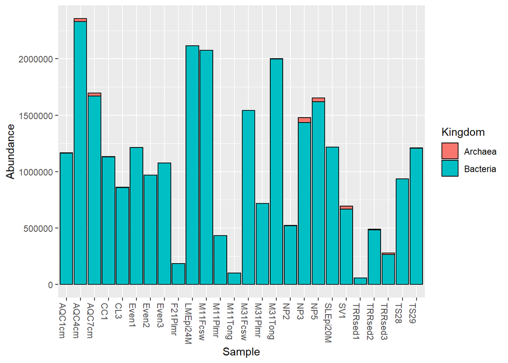

```r
plot_bar(dataKingdom, fill="Kingdom")
```

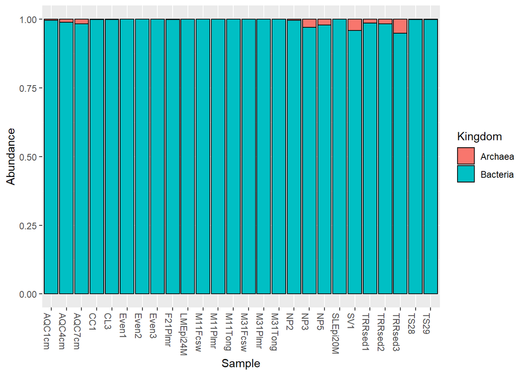

```r
plot_bar(propdataKingdom, fill="Kingdom")
```

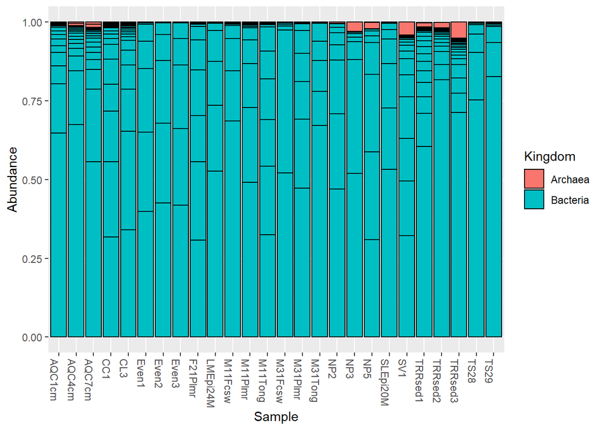

```r
plot_bar(propdataPhylum, fill="Kingdom")
```

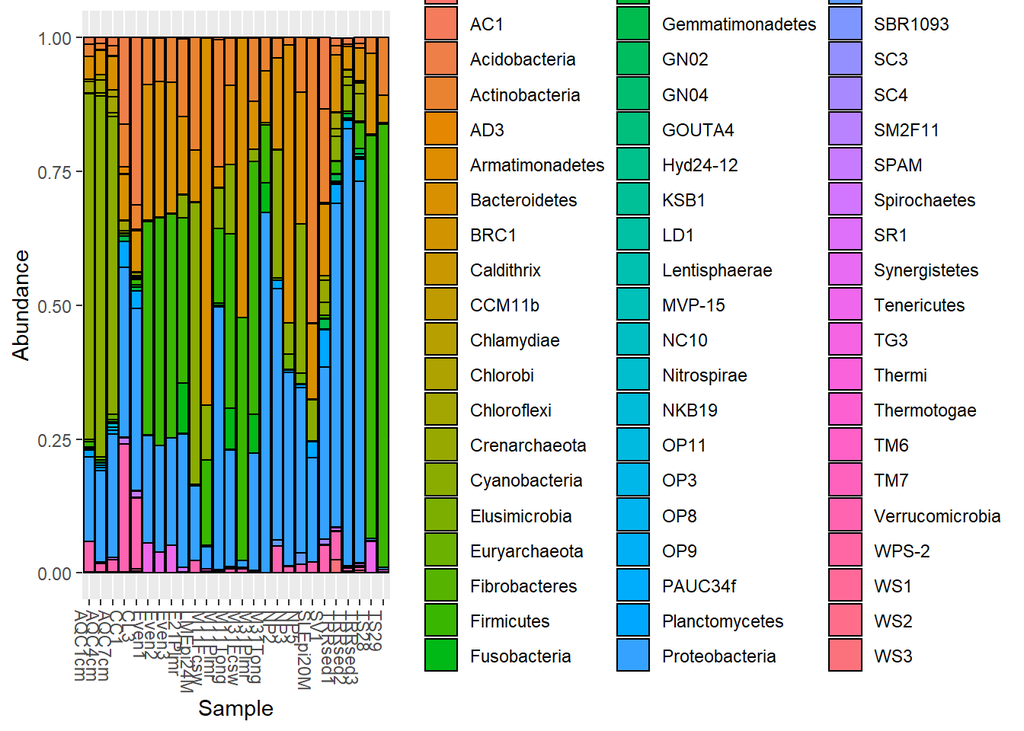

```r
plot_bar(propdataPhylum, fill="Phylum")
```

Bar plot with R function `barplot()`:

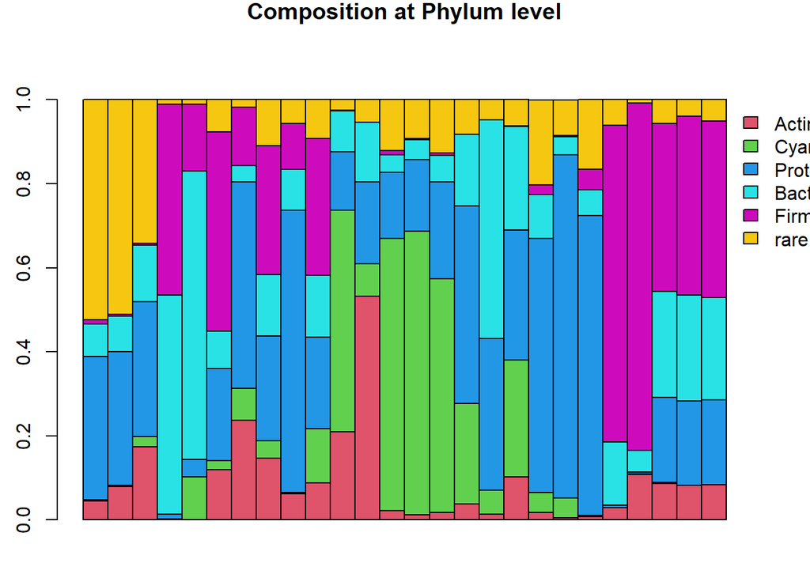

```r
par(xpd=TRUE, mar= c(5, 4, 4, 7) + 0.1, pin=c(6,4))
barplot(otu2, ylim=c(0,1.1), col=2:7, beside=FALSE, space=0, las=3,
        xlab="", ylab="%", main="Composition at Phylum level",xaxt="n")
legend(26,1,legend=rownames(otu2), fill=2:7, bty="n")
```

```r
par(default.par)
```

## 4.2 Box plot

Box plot of abundances by Phylum level for human samples:

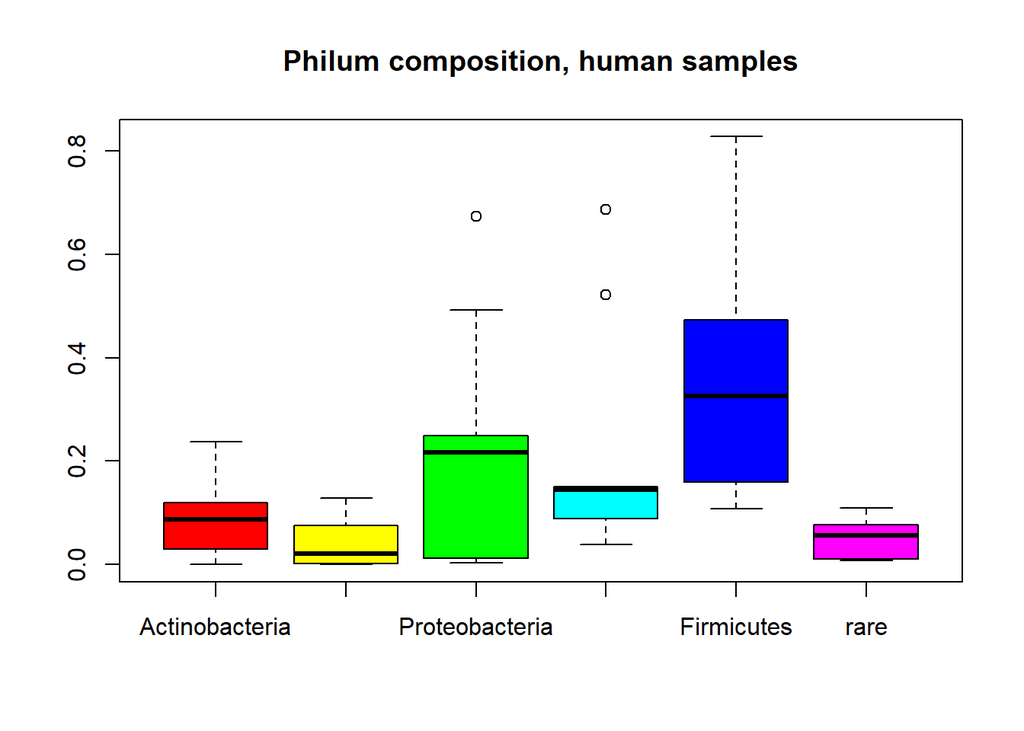

```r
boxplot(as.data.frame(t(otu2)[sample_data(data)$human=="Yes",]), col=rainbow(6))
title("Philum composition, human samples")
```

Box plot abundances by Phylum level for non human samples:

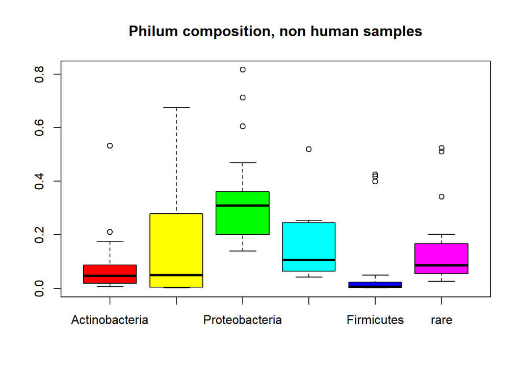

```r
boxplot(as.data.frame(t(otu2)[sample_data(data)$human=="No",]), col=rainbow(6))
title("Philum composition, non human samples")
```

## 4.3 Heatmap

Heatmap: Abundance plots of taxa by sample

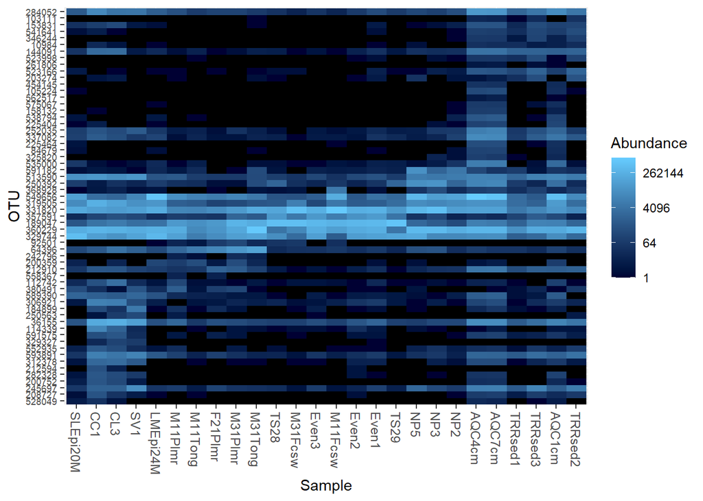

```r
plot_heatmap(dataPhylum)
```

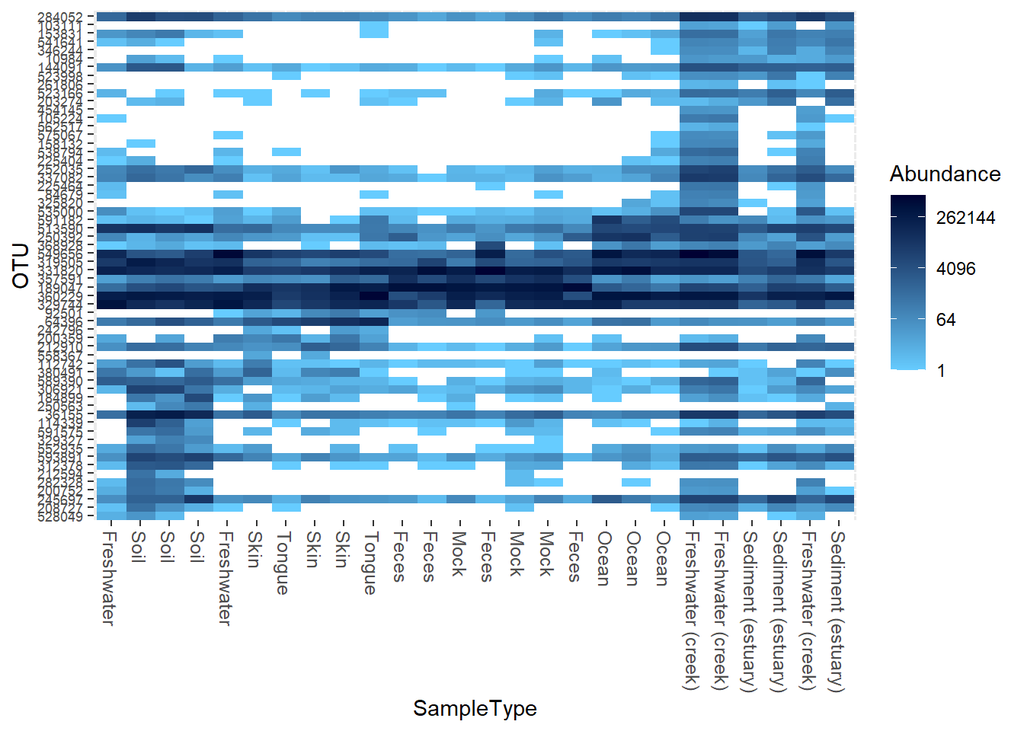

```r
plot_heatmap(dataPhylum,sample.label="SampleType",  low="#66CCFF",high="#000033", na.value="white")
```

# 5 Phylogenetic tree

*Example*: Phylogenetic tree for Phylum = “Acidobacteria” and abundances aglomerated at “Class” level:

Agglomerate data at “Class” level:

```r
dataClass<-tax_glom(data, "Class")
```

Consider the subset of taxa called “d” corresponding to Acidobacteria Phylum:

```r
d<-subset_taxa(dataClass, Phylum =="Acidobacteria")
```

Plot phylogenetic tree for “d”:

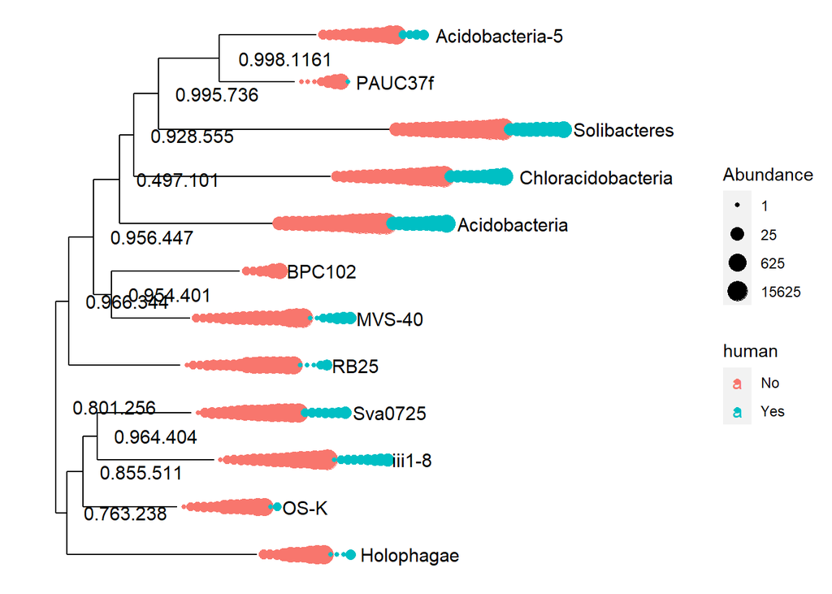

```r
plot_tree(d,ladderize="left",size="abundance",color="human",label.tips="Class")
```

# 6 Alpha diversity: within sample diversity

Estimate different alpha diversity measures:

```r
rich<-estimate_richness(data, measures =c("Observed", "Chao1", "Shannon"))
head(rich)
```

```
##         Observed    Chao1  se.chao1  Shannon
## CL3         5896 6857.224  85.33045 6.556505
## CC1         6484 7243.788  68.85921 6.761077
## SV1         4865 5806.021  81.37250 6.480832
## M31Fcsw     2165 3206.857 107.40244 3.821896
## M11Fcsw     2098 3239.768 115.67864 3.282408
## M31Plmr     2780 3846.735 104.10759 4.277283
```

Plot different alpha diversity measures:

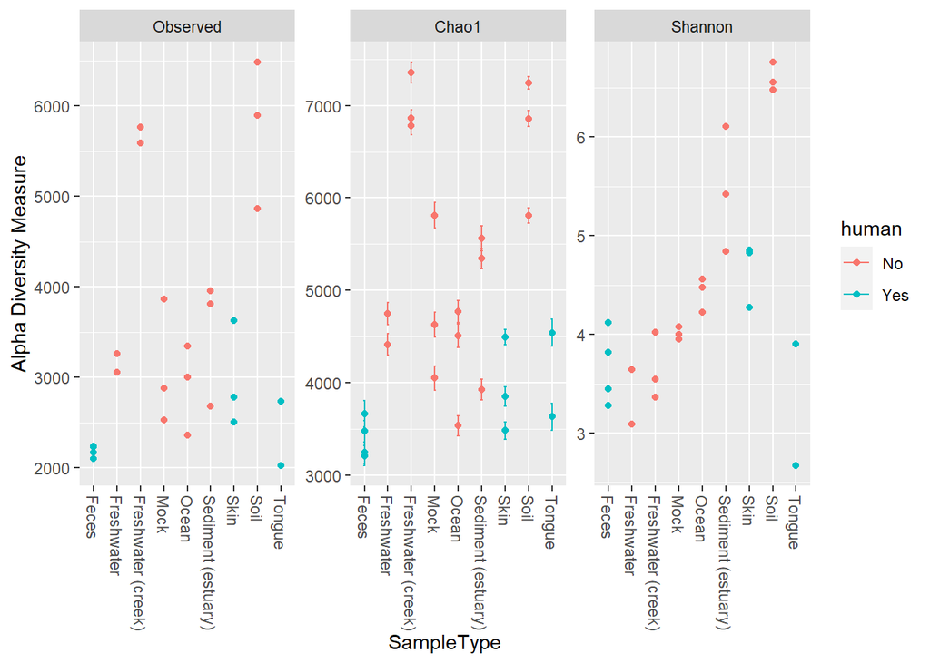

```r
plot_richness(data, x="SampleType", measures=c("Observed","Chao1","Shannon"), color="human")
```

Explore alpha diversity (observed number of species) as a function of sample size:

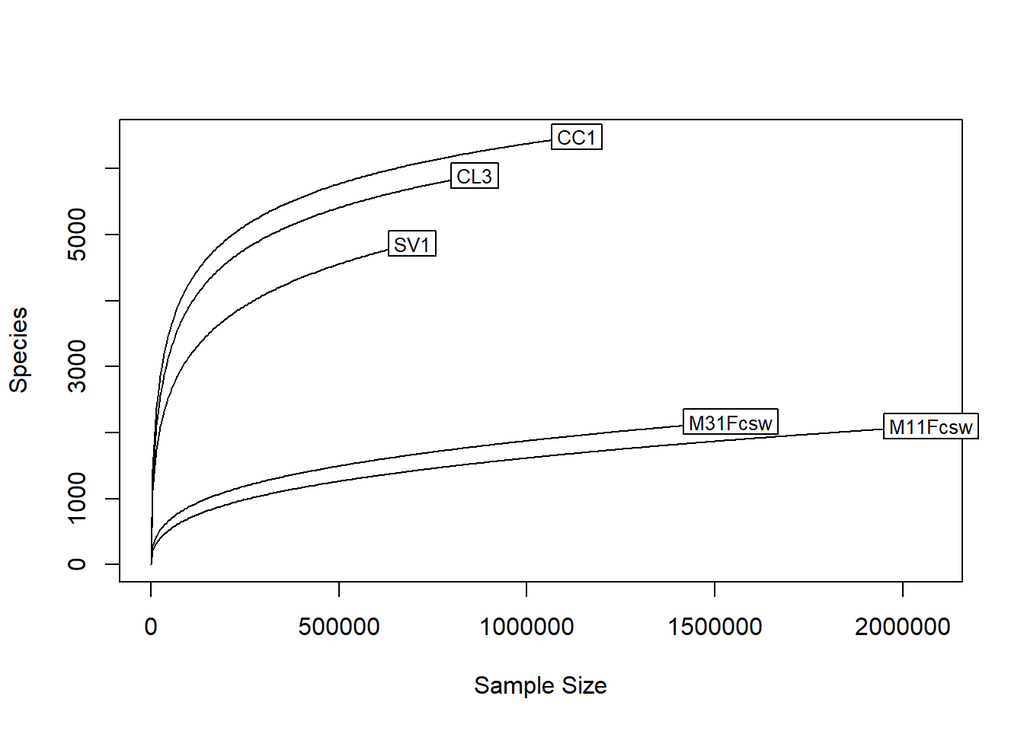

```r
rarecurve(t(otu_table(data))[1:5,],step=5000)
```

Compare Shannon diversity between human and non-human samples with a boxplot:

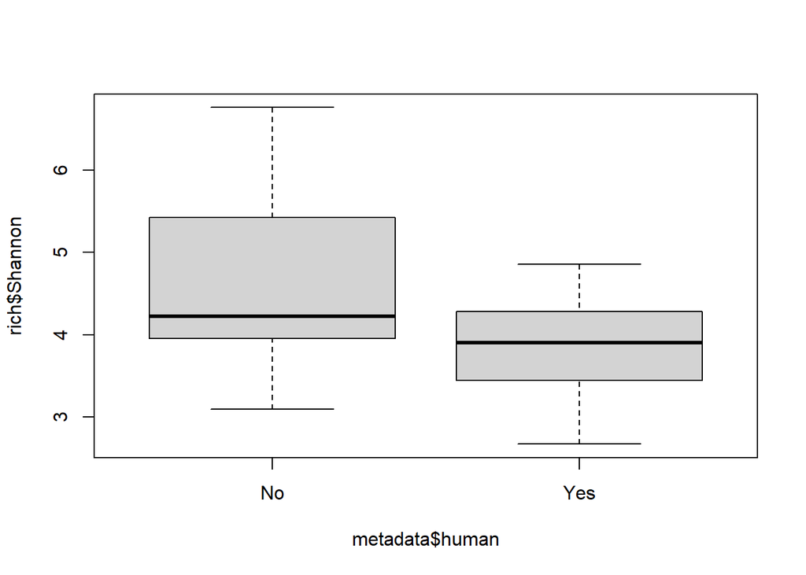

```r
boxplot(rich$Shannon~metadata$human)
```

Wilcoxon test for differences in Shannon diversity between human and non-human samples:

```r
wilcox.test(rich$Shannon~metadata$human)
```

```
##
##  Wilcoxon rank sum exact test
##
## data:  rich$Shannon by metadata$human
## W = 102, p-value = 0.1815
## alternative hypothesis: true location shift is not equal to 0
```

Compare Shannon diversity according to sample type with a boxplot:

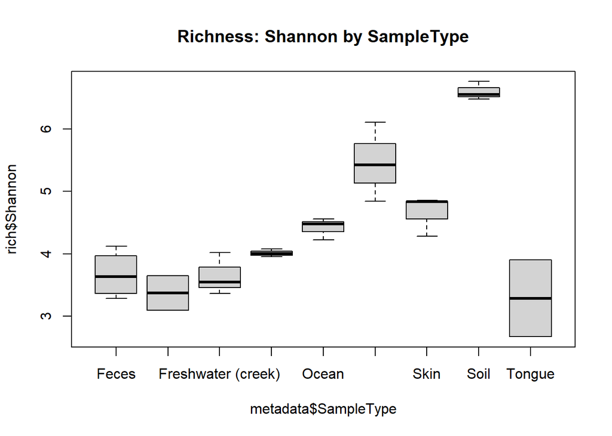

```r
boxplot(rich$Shannon~metadata$SampleType)
title("Richness: Shannon by SampleType")
```

Pairwise Wilcoxon test for differences in Shannon diversity between different sample types and FDR multiple testing adjustment:

```r
pairwise.wilcox.test(rich$Shannon, metadata$SampleType, p.adjust.method ="fdr")
```

```
##
##  Pairwise comparisons using Wilcoxon rank sum exact test
##
## data:  rich$Shannon and metadata$SampleType
##
##                    Feces Freshwater Freshwater (creek) Mock Ocean
## Freshwater         0.62  -          -                  -    -
## Freshwater (creek) 1.00  0.85       -                  -    -
## Mock               0.48  0.27       0.48               -    -
## Ocean              0.22  0.27       0.22               0.22 -
## Sediment (estuary) 0.22  0.27       0.22               0.22 0.22
## Skin               0.22  0.27       0.22               0.22 0.48
## Soil               0.22  0.27       0.22               0.22 0.22
## Tongue             0.85  1.00       0.85               0.27 0.27
##                    Sediment (estuary) Skin Soil
## Freshwater         -                  -    -
## Freshwater (creek) -                  -    -
## Mock               -                  -    -
## Ocean              -                  -    -
## Sediment (estuary) -                  -    -
## Skin               0.27               -    -
## Soil               0.22               0.22 -
## Tongue             0.27               0.27 0.27
##
## P value adjustment method: fdr
```

# 7 Beta diversity: between samples diversity

Estimate different beta diversity measures with function `distance`. Most common distances used are Bray-Curtis, Unifrac and weighted Unifrac.

Estimate Bray-Curtis distance:

```r
BC.dist<-distance(data, method ="bray")

as.matrix(BC.dist)[1,2]
```

```
## [1] 0.5984077
```

Estimate Unifrac distance:

```r
UF.dist<-distance(data, method = "unifrac")
```

Estimate weighted Unifrac distance:

```r
wUF.dist<-distance(data, method = "wunifrac")
```

# 8 Ordination: Visualization of beta diversity

## 8.1 Principal Coordinates Analysis (PCoA) = Multidimensional Scaling (MDS)

*Example*: MDS for human samples

Define as “data.human” the subset of samples corresponding to human samples (feces, skin and tongue:

```r
data.human<-subset_samples(data, human=="Yes")
```

Estimate Bray-Curtis distance among human samples:

```r
BC.dist.human<-distance(data.human, method ="bray")
```

Perform MDS ordination of human samples with BC distance:

```r
BC.MDS.human=ordinate(data.human,   "MDS",  distance    =   BC.dist.human)
```

Plot MDS ordination of human samples with BC distance:

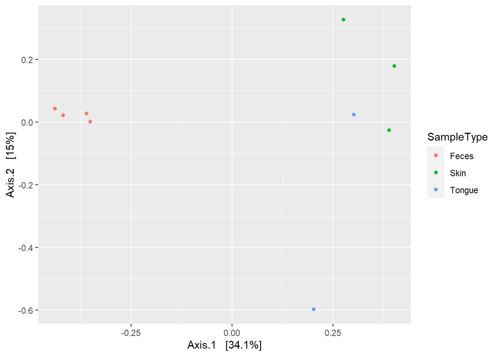

```r
plot_ordination(data.human, BC.MDS.human,   color="SampleType")
```

Estimate Unifrac distance among human samples:

```r
UF.dist.human<-distance(data.human, method ="unifrac")
```

Perform MDS ordination of human samples with UF distance:

```r
UF.MDS.human=ordinate(data.human,   "MDS",  distance    =   UF.dist.human)
```

Plot MDS ordination of human samples with UF distance:

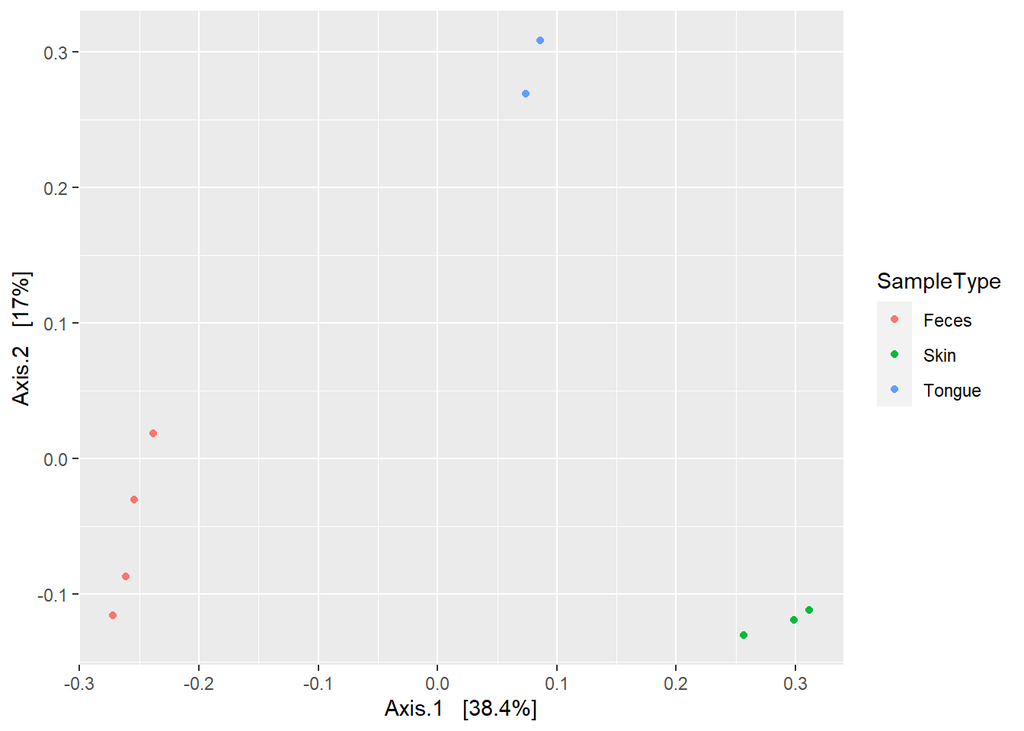

```r
plot_ordination(data.human, UF.MDS.human,   color="SampleType")
```

Estimate weighted Unifrac distance among human samples:

```r
wUF.dist.human<-distance(data.human, method ="wunifrac")
```

Perform MDS ordination of human samples with wUF distance:

```r
wUF.MDS.human=ordinate(data.human,  "MDS",  distance    =   wUF.dist.human)
```

Plot MDS ordination of human samples with wUF distance:

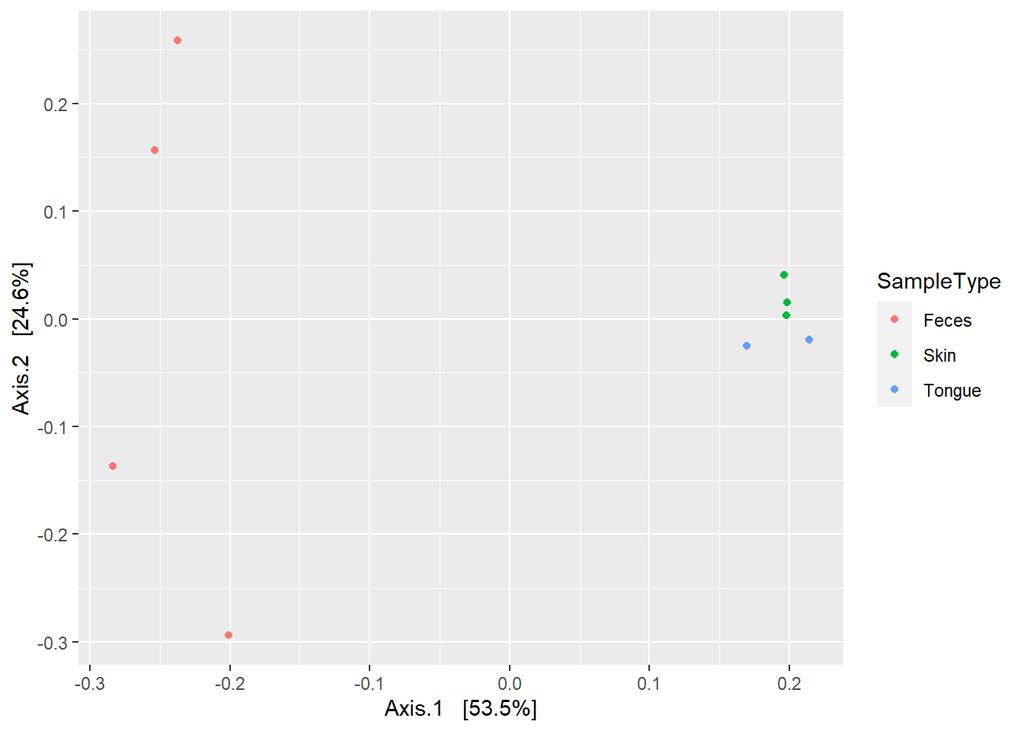

```r
plot_ordination(data.human, wUF.MDS.human,  color="SampleType")
```

## 8.2 Nonmetric Multidimensional Scaling (NMDS)

*Example*: NMDS for human samples

Perform NMDS ordination of human samples with wUF distance:

```r
wUF.NMDS.human=ordinate(data.human, "NMDS", distance    =   wUF.dist.human)
```

```
## *** Solution reached
```

Plot NMDS ordination of human samples with wUF distance:

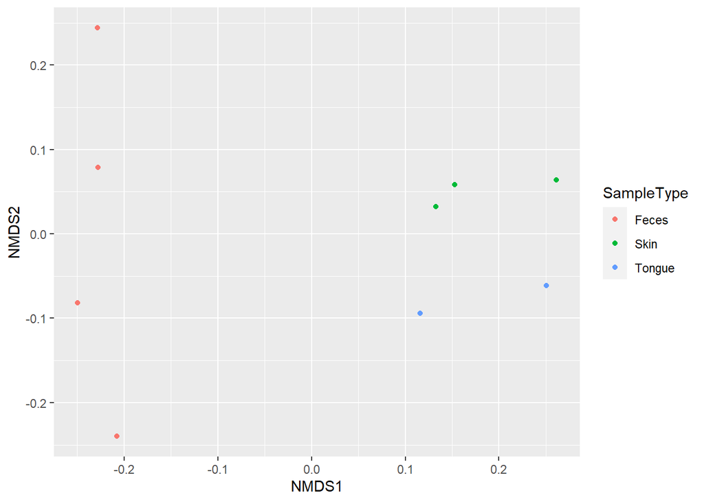

```r
plot_ordination(data.human, wUF.NMDS.human, color="SampleType")
```

# 9 Multivariate differential abundance testing

## 9.1 Test Adonis

Multivariate ANOVA based on dissimilarities (PERMANOVA) using vegan function `adonis()`:

```r
test.adonis<-adonis(BC.dist.human~sample_data(data.human)$SampleType)
```

```
## 'adonis' will be deprecated: use 'adonis2' instead
```

```r
test.adonis
```

```
## $aov.tab
## Permutation: free
## Number of permutations: 999
##
## Terms added sequentially (first to last)
##
##                                    Df SumsOfSqs MeanSqs F.Model      R2 Pr(>F)
## sample_data(data.human)$SampleType  2    1.5534 0.77670  2.6042 0.46469  0.002
## Residuals                           6    1.7895 0.29825         0.53531
## Total                               8    3.3429                 1.00000
##
## sample_data(data.human)$SampleType **
## Residuals
## Total
## ---
```

[output cut: 1067 more lines]

# 10 coda4microbiome: Compositional data analysis of microbiome cross-sectional studies

https://malucalle.github.io/statistical-pills/coda4microbiome_cross_sectional.html

# 11 coda4microbiome: Compositional data analysis of microbiome longitudinal studies

https://malucalle.github.io/statistical-pills/coda4microbiome_longitudinal.html